# Actividad 2

Lote 34 Equipo 4: Jennifer Tatiana Gutierrez Lizarazo, Angela Patricia Cadena Ramírez, Ciro Antonio Medina Barrera

2025-04-19

Importar librerías

```r
library(readr) # Leer datos
library(tidyverse) #Manejo y graficado de datos
library(ConvergenceClubs)
```

Importar data

```r
data <- read_csv("dataset_provincias.csv")
```

```
## ──────────────────────────────────────────────────────── Delimiter: "," chr
## (1): Provincias dbl (9): ...1, Year, Mes, dia, Población, Unidades, Euros,
## precio, UdesxCapita date (1): fecha
```

```r
# view(data) # Mostrar data

# Eliminar la primera columna
data <- data %>%
  select(-1)
```

# 1. ¿De qué tipo de variables se compone el dataset? Realiza una representación gráfica que permita conocer el comportamiento de la serie temporal de las ventas de cigarrillos en cada una de las provincias. Describe brevemente los hallazgos más relevantes tras este conocimiento inicial.

```r
summary(data)
```

```
##   Provincias             Year           Mes             dia
##  Length:9792        Min.   :2005   Min.   : 1.00   Min.   :15
##  Class :character   1st Qu.:2009   1st Qu.: 3.75   1st Qu.:15
##  Mode  :character   Median :2013   Median : 6.50   Median :15
##                     Mean   :2013   Mean   : 6.50   Mean   :15
##                     3rd Qu.:2017   3rd Qu.: 9.25   3rd Qu.:15
##                     Max.   :2021   Max.   :12.00   Max.   :15
##      fecha              Población          Unidades            Euros
##  Min.   :2005-01-15   Min.   :  81661   Min.   :  241515   Min.   :   977137
##  1st Qu.:2009-04-07   1st Qu.: 307011   1st Qu.: 1646447   1st Qu.:  5973650
##  Median :2013-06-30   Median : 514117   Median : 3196861   Median : 12138093
##  Mean   :2013-06-30   Mean   : 778907   Mean   : 5281778   Mean   : 18340272
##  3rd Qu.:2017-09-22   3rd Qu.: 840690   3rd Qu.: 5895038   3rd Qu.: 20159390
##  Max.   :2021-12-15   Max.   :5737647   Max.   :53098349   Max.   :141386591
##      precio       UdesxCapita
##  Min.   :1.886   Min.   : 2.098
##  1st Qu.:2.689   1st Qu.: 4.684
##  Median :4.294   Median : 5.847
##  Mean   :3.752   Mean   : 6.988
##  3rd Qu.:4.505   3rd Qu.: 8.396
##  Max.   :4.694   Max.   :60.295
```

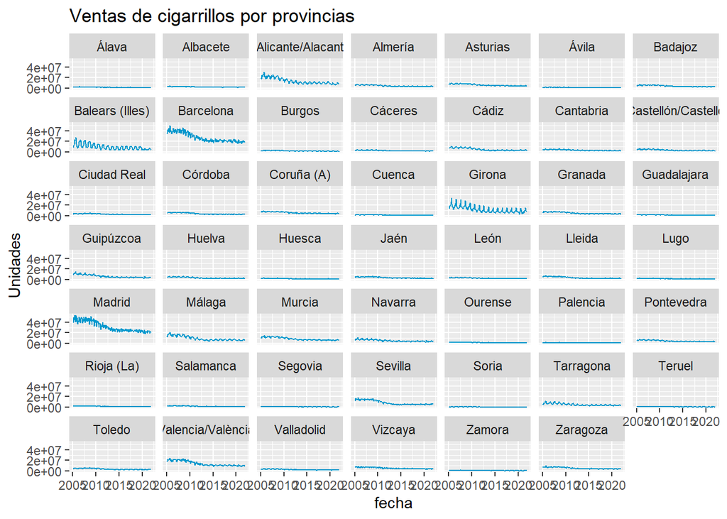

```r
data %>%
  ggplot( aes(x= fecha, y= Unidades))+
  geom_line(color="#0098cd")+
  facet_wrap(~Provincias)+
  labs(title = "Ventas de cigarrillos por provincias")
```

# 2. Haz una representación gráfica que permita conocer, de forma ordenada, cuál es el ranking de las provincias de más a menos venta (toma como referencia la media de UdesxCapita).

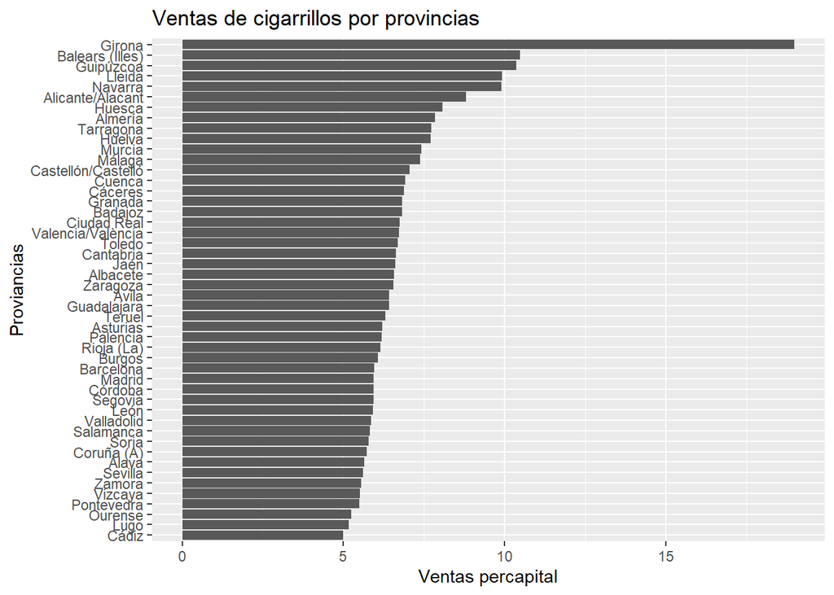

```r
data %>%
  filter(!is.na(Provincias)) %>%
  group_by(Provincias) %>%
  summarise(avg_UndesxCapita = mean(UdesxCapita, na.rm =TRUE)) %>%
  ggplot(aes( x= avg_UndesxCapita, y= reorder(x=Provincias, avg_UndesxCapita)))+
  geom_col()+
  labs(title = "Ventas de cigarrillos por provincias")+
  ylab("Proviancias")+
  xlab("Ventas percapital")
```

**Comentarios:**

- La provincia con más ventas es Girona
- la provincia con menor venta es Cadiz

# 3. La dirección general quiere llevar a cabo acciones diferenciadas en las distintas provincias españolas. Por ello, se le pregunta, ¿podemos decir que existe convergencia absoluta (las ventas por provincia se comportan de manera homogénea) en las ventas de cigarrillos? En base a los resultados alcanzados, ¿qué podemos contestar a la dirección general? ¿Se pueden llevar a cabo acciones diferenciadas?

```r
#validar valores faltantes
sum(is.na(data$Provincias))
```

```
## [1] 0
```

## para este análisis se toma la variable Unidades, dado que esta es la que representa las ventas en cajetillas de cigarrillos.

```r
# la librería requiere pasar de formato "long" o largo a "wide" ancho
data_wide <- data %>%
  pivot_wider(id_cols = c(Provincias), # Se coloca la c para crear vectores
    names_from = fecha, values_from = Unidades)
```

Posteriormente se dispone a aplicar logaritmos para suavizar la serie temporal, menos la la columna 1 o columna de provincias.

```r
#Se aplica el log a todo el dataframe menos a la primera columna
log_ <- log(data_wide[,-1])

#Une la variable proviancias al dataframe log
log_wide <- data.frame(provincias= data_wide[,1], log_)

# se fija la columna provincias como indice para identificar mejor los clubs de convergencia
row.names(log_wide) <- log_wide[,1]

# Eliminar valores faltantes
log_wide <- drop_na(log_wide)
```

## Prurba de convergencia apsoluta

Nota: l primera columna no se tiene en cuenta para el análisis

La función computeH calcula el exponente de Hurst (H) para cada columna. Este valor (entre 0 y 1) mide:

- H ≈ 0.5: Comportamiento aleatorio (ej: acciones).
- H > 0.5: Persistencia (ej: tendencias fuertes en ventas).
- H < 0.5: Anti-persistencia (ej: fluctuaciones erráticas).
- `time_trim = 1/3>` Recorta el primer tercio, de los datos para reducir el ruido “En este caso, 1/3 indica que se eliminará el 33% de los puntos en ambos extremos al ajustar el modelo.”
- Emplea FQSB (método robusto) para corregir autocorrelación y heterocasticidad

**Este modelo realiza un contraste entre:**

$Ho$ Las series presentan convergencia absoluta

$Ha$ Las series no presentan convergencia absoluta

```r
# Paso 1: Calculamos el exponente de Hurst
H <- computeH(log_wide[,-1],quantity = "H")

# Paso 2: Estimamos el modelo de convergencia.
round(estimateMod(H,time_trim = 1/3, HACmethod = "FQSB"),3)
```

```
##    beta std.err  tvalue  pvalue
##  -0.459   0.014 -31.663   0.000
```

**Respuesta:**

- Dado su $P−value$ se rechaza la hipótesis nula, por lo tanto, se puede afirmar estadísticamente que no existe convergencia absoluta
- No se puede llevar a cabo una dirección general en cuanto a la estrategias de ventas para todas las provincias, se requiere segmentar las provincias para hallar similitudes en el comportamiento de ventas.

# 4 ¿En el caso de que no exista convergencia absoluta, en cuántos grupos (clubes) podemos dividir las provincias en función al comportamiento de las series temporales? ¿Existe algún patrón de comportamiento geográfico y/o relacionado con el ranking elaborado en el segundo apartado?

CLUBES DE CONVERGENCIA

```r
clubsprovincias <- findClubs(log_wide,
                         dataCol = 2:205, # toma de la columna 2 hasta la 205 "la 1 es la que tiene los nombres"
                         unit_names = 1, # Señala la comuna con los nombres (Provincias)
                         refCol = 205,  # Usa la última columna, como referencia para ordenar las unidades.
                         time_trim = 1/3, # elimina el 33% de los datos en los extremos
                         cstar = 0,  # Unidades con comportamiento similar al promedio del grupo de referencia se incluyen en el primer club
                         HACmethod = "FQSB") #corregir auto correlación y heterosexualidad en las regresiones
```

resumen de lo culbs

```r
summary(clubsprovincias)
```

```
## Number of convergence clubs: 9
## Number of divergent units: 1
##
##         | # of units  | beta     | std.err  | tvalue   | cstar
## -------- ------------- ---------- ---------- ---------- --------
##  club1  |   2         |   0.361  |   0.294  |   1.226  |   0
##  club2  |   4         |  -0.195  |   0.157  |  -1.244  |   0
##  club3  |   5         |  -0.233  |   0.163  |  -1.43   |   0
##  club4  |   8         |   0.012  |   0.089  |   0.129  |   0
##  club5  |   4         |  -0.6    |   0.391  |  -1.533  |   0
##  club6  |   11        |   0.043  |   0.045  |   0.969  |   0
##  club7  |   6         |   0.222  |   0.067  |   3.32   |   0
##  club8  |   2         |  -0.176  |   0.408  |  -0.431  |   0
##  club9  |   5         |   0.237  |   0.134  |   1.766  |   0
```

```r
print(clubsprovincias) # Mostrar el desglosar de los blups
```

```
## ========================================================================
## club 1
## ------------------------------------------------------------------------
## Madrid, Barcelona
##
## beta:      0.3606
## std.err:   0.2943
## tvalue:    1.2255
## pvalue:    0.8898
## cstar:     0
##
## ========================================================================
## club 2
## ------------------------------------------------------------------------
## Valencia/València, Girona, Alicante/Alacant, Málaga
##
## beta:     -0.1951
## std.err:   0.1568
## tvalue:   -1.2442
## pvalue:    0.1067
## cstar:     0
##
## ========================================================================
## club 3
## ------------------------------------------------------------------------
## Murcia, Sevilla, Vizcaya, Coruña (A), Asturias
##
## beta:     -0.2325
## std.err:   0.1625
## tvalue:   -1.4305
## pvalue:    0.0763
## cstar:     0
##
## ========================================================================
## club 4
## ------------------------------------------------------------------------
## Guipúzcoa, Navarra, Cádiz, Almería, Tarragona, Pontevedra, Toledo,
## Castellón/Castelló
##
## beta:      0.0116
```

[output cut: 50 more lines]

```
## ========================================================================
## club 9
## ------------------------------------------------------------------------
## Zamora, Ávila, Palencia, Teruel, Segovia
##
## beta:      0.2368
## std.err:   0.1341
## tvalue:    1.766
## pvalue:    0.9613
## cstar:     0
##
## ========================================================================
## divergent
## ------------------------------------------------------------------------
## Soria
```

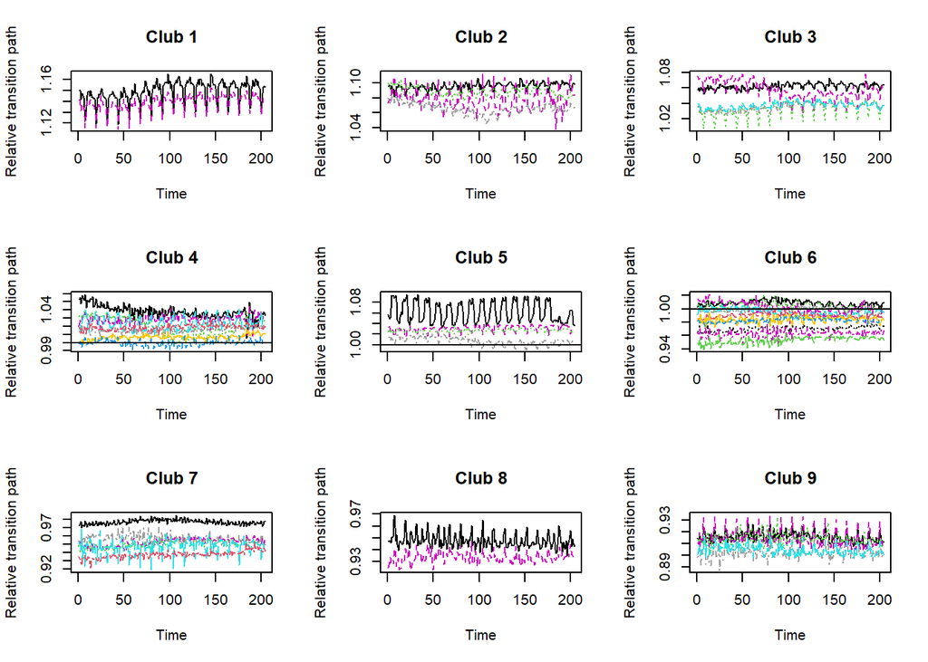

```r
plot(clubsprovincias, avgTP = FALSE, nrows = 3, ncols = 3, plot_args = list(type='l'))
```

Gráfica de las tendencias de las provincias

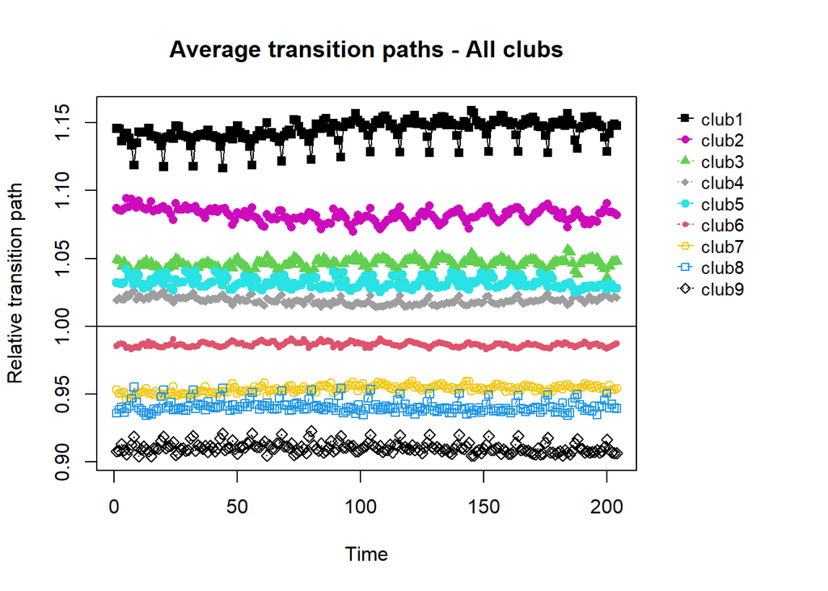

```r
plot(clubsprovincias, clubs = NULL, avgTP = TRUE, legend = TRUE, plot_args = list(type='o'))
```

```r
mcclubsprovincias <- mergeClubs(clubsprovincias,
                            mergeMethod = 'PS',
                            threshold = -1.65,
                            mergeDivergent = FALSE)

summary(mcclubsprovincias)
```

```
## Number of convergence clubs: 7
## Number of divergent units: 1
##
##         | merged clubs  | # of units  | beta     | std.err  | tvalue
## -------- --------------- ------------- ---------- ---------- ----------
##  club1  | clubs: 1      |   2         |   0.361  |   0.294  |   1.226
##  club2  | clubs: 2      |   4         |  -0.195  |   0.157  |  -1.244
##  club3  | clubs: 3      |   5         |  -0.233  |   0.163  |  -1.43
##  club4  | clubs: 4, 5   |   12        |  -0.174  |   0.265  |  -0.658
##  club5  | clubs: 6      |   11        |   0.043  |   0.045  |   0.969
##  club6  | clubs: 7, 8   |   8         |  -0.013  |   0.045  |  -0.299
##  club7  | clubs: 9      |   5         |   0.237  |   0.134  |   1.766
```

```r
print(mcclubsprovincias)
```

```
## ========================================================================
## club 1
## ------------------------------------------------------------------------
## Madrid, Barcelona
##
## beta:      0.3606
## std.err:   0.2943
## tvalue:    1.2255
## pvalue:    0.8898
##
## ========================================================================
## club 2
## ------------------------------------------------------------------------
## Valencia/València, Girona, Alicante/Alacant, Málaga
##
## beta:     -0.1951
## std.err:   0.1568
## tvalue:   -1.2442
## pvalue:    0.1067
##
## ========================================================================
## club 3
## ------------------------------------------------------------------------
## Murcia, Sevilla, Vizcaya, Coruña (A), Asturias
##
## beta:     -0.2325
## std.err:   0.1625
## tvalue:   -1.4305
## pvalue:    0.0763
##
## ========================================================================
## club 4
## ------------------------------------------------------------------------
## Guipúzcoa, Navarra, Cádiz, Almería, Tarragona, Pontevedra, Toledo,
## Castellón/Castelló, Balears (Illes), Zaragoza, Granada, Córdoba
##
## beta:     -0.174
## std.err:   0.2646
## tvalue:   -0.6577
## pvalue:    0.2554
```

[output cut: 21 more lines]

```
##
## ========================================================================
## club 7
## ------------------------------------------------------------------------
## Zamora, Ávila, Palencia, Teruel, Segovia
##
## beta:      0.2368
## std.err:   0.1341
## tvalue:    1.766
## pvalue:    0.9613
##
## ========================================================================
## divergent
## ------------------------------------------------------------------------
## Soria
```

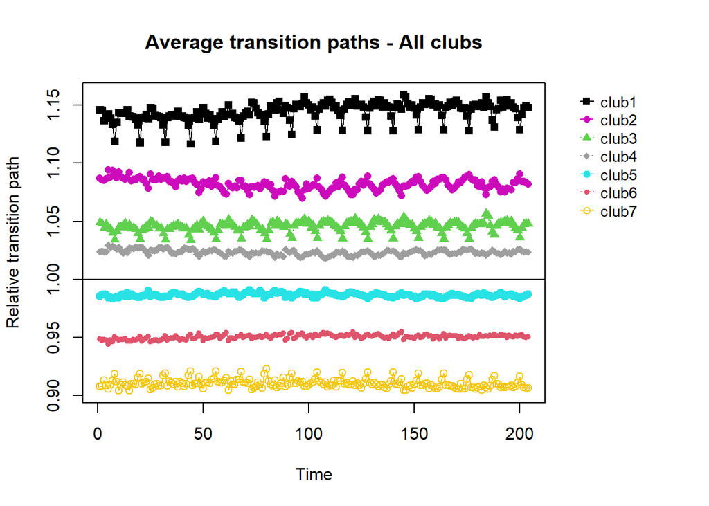

```r
#gráfica de clubes
plot(mcclubsprovincias, clubs = NULL, avgTP = TRUE, legend = TRUE, plot_args = list(type='o'))
```

Al aplicar el método de merge, se redujeron los clubs de 9 a 7.

```r
# Obtener las proviancias del club 7
mcclubsprovincias$club1
```

```
## $clubs
## [1] "club1"
##
## $id
## [1] 29  9
##
## $model
##      beta   std.err    tvalue    pvalue
## 0.3606173 0.2942595 1.2255076 0.8898080
##
## $unit_names
## [1] "Madrid"    "Barcelona"
```

```r
# Obtener las proviancias de clubs
clubsprovincias$club9
```

```
## $id
## [1] 47  6 34 42 38
##
## $model
##      beta   std.err    tvalue    pvalue
## 0.2368085 0.1340920 1.7660146 0.9613033
##
## $cstar
## [1] 0
##
## $unit_names
## [1] "Zamora"   "Ávila"    "Palencia" "Teruel"   "Segovia"
```

# 5.Haz una predicción a 12 meses para, como mínimo, una provincia de cada club, ¿Hay clubes cuyas series temporales sean más fácilmente predecibles que otras? Justifica tu respuesta.

Importar librerías

```r
library(forecast)
library(tseries)
```

## Forecast Madrid

Elección de la primera serie temporal

```r
Madrid <- data[data$Provincias == "Madrid",] # Seleccionar la data de madrid

Madrid_ts <- ts(Madrid$Unidades, start = c(2005, 1), frequency = 12)  #dar formato datatime a la data
```

## Graficar la serie temporal de madrid club_1

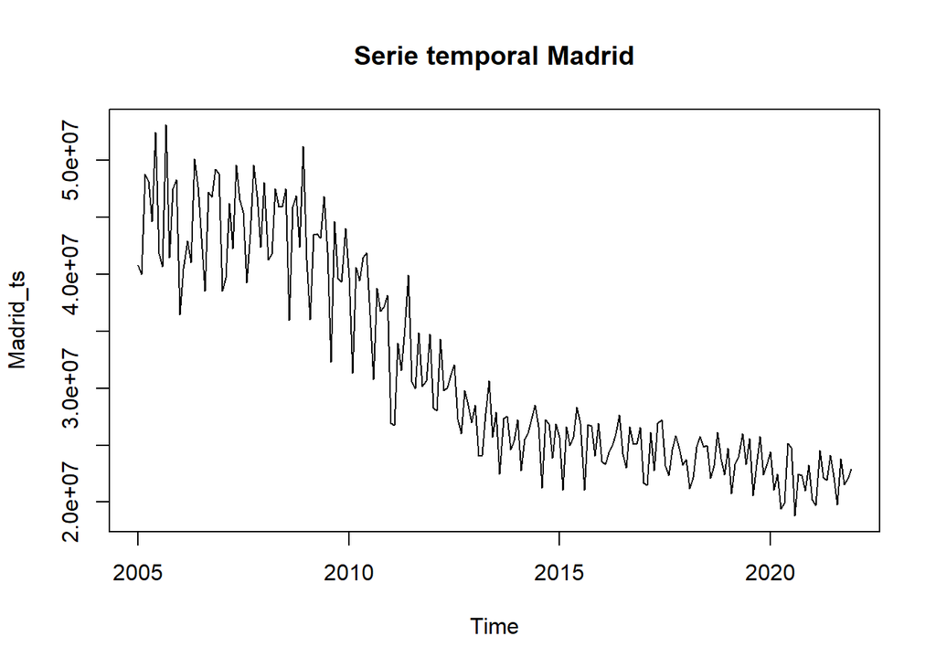

```r
plot(Madrid_ts, main="Serie temporal Madrid")
```

```r
# Aplicar el test ADF
print (adf.test(Madrid_ts))
```

```
##
##  Augmented Dickey-Fuller Test
##
## data:  Madrid_ts
## Dickey-Fuller = -0.6338, Lag order = 5, p-value = 0.975
## alternative hypothesis: stationary
```

Aparentemente la serie no es estacionaria, a continuación se comprobará con la prueba Dickey-Fuller

Se comprueba sistemáticamente que la serie no cumple el supuesto de estacionariedad, por ende se procese a realizar diferencias.

```r
modelo_arima_madrid <- auto.arima(Madrid_ts)
print(modelo_arima_madrid) # Mostrar el output del modelo
```

```
## Series: Madrid_ts
## ARIMA(5,1,4)(2,0,0)[12]
##
## Coefficients:
##           ar1      ar2      ar3      ar4      ar5     ma1      ma2     ma3
##       -1.0064  -0.8321  -0.5611  -0.6729  -0.4843  0.0801  -0.1861  0.1168
## s.e.   0.1957   0.1813   0.2340   0.1685   0.1435  0.2019   0.1670  0.1984
##          ma4    sar1    sar2
##       0.1099  0.3213  0.3573
## s.e.  0.1173  0.0799  0.0762
##
## sigma^2 = 4.9e+12:  log likelihood = -3253.12
## AIC=6530.24   AICc=6531.89   BIC=6570
```

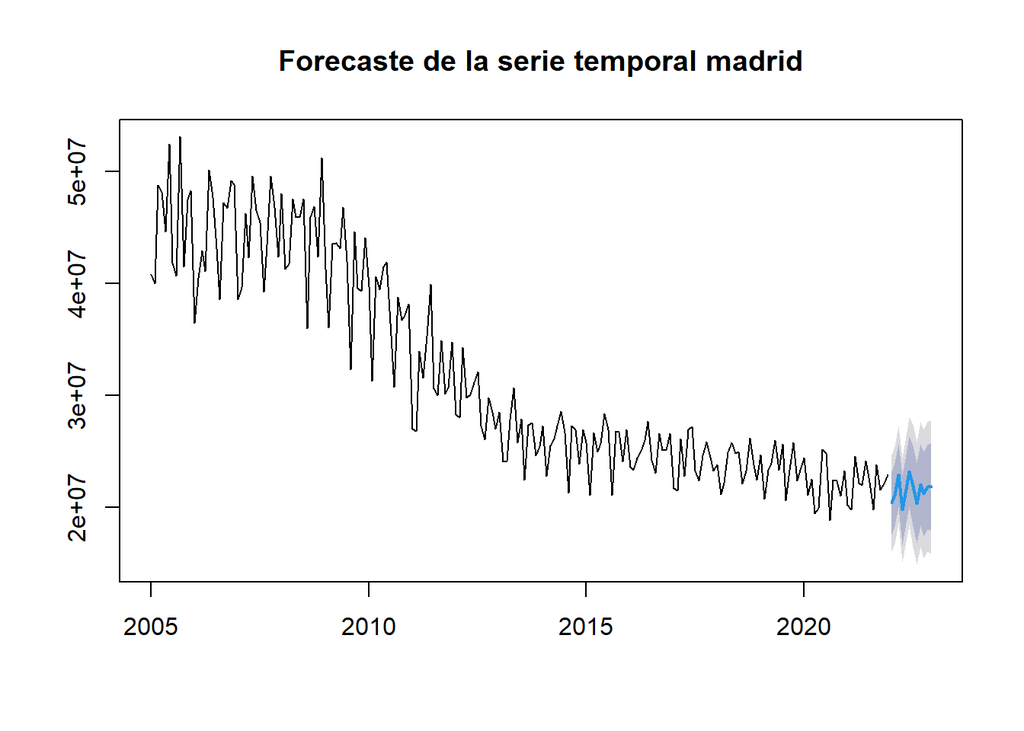

```r
prediccion_madrid <- forecast(modelo_arima_madrid,12)
plot(prediccion_madrid, main="Forecaste de la serie temporal madrid") # graficar la predicción
```

```r
# Print valores de forcast
prediccion_madrid$mean
```

```
##           Jan      Feb      Mar      Apr      May      Jun      Jul      Aug
## 2022 20359129 21084889 22878191 19736950 21604906 23173600 21885797 20342957
##           Sep      Oct      Nov      Dec
## 2022 22002254 21166415 21795233 21820920
```

Revisar loe errores del modelo

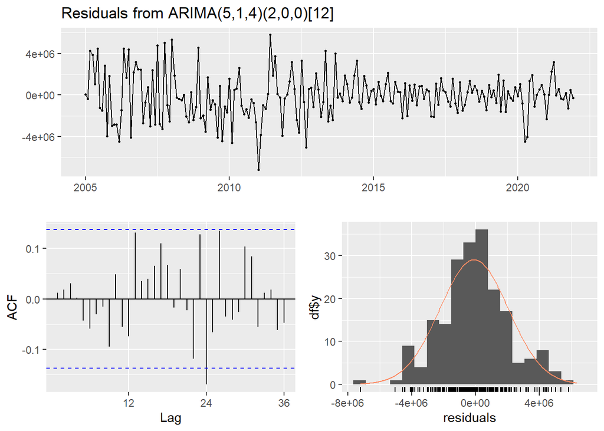

```
##
##  Ljung-Box test
##
## data:  Residuals from ARIMA(5,1,4)(2,0,0)[12]
## Q* = 29.888, df = 13, p-value = 0.004889
##
## Model df: 11.   Total lags used: 24
```

```r
checkresiduals(modelo_arima_madrid)
```

## Forecast Valencia club_2

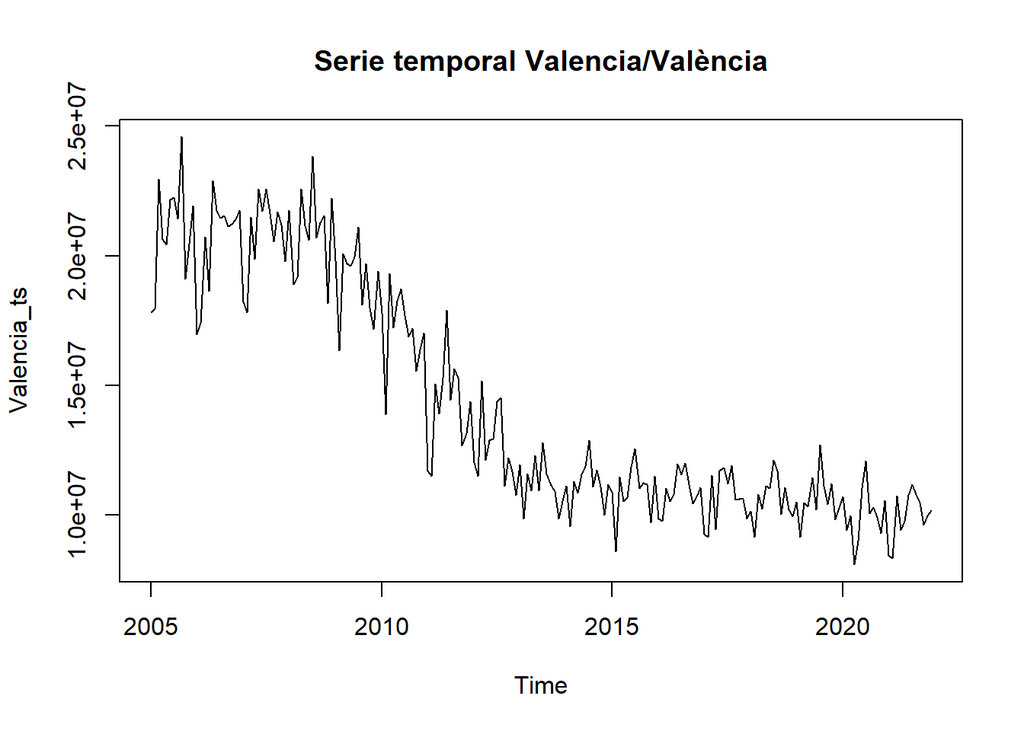

```r
Valencia <- data[data$Provincias == "Valencia/València",] # Seleccionar la data de valencia

Valencia_ts <- ts(Valencia$Unidades, start = c(2005, 1), frequency = 12)  #dar formato datatime a la data

plot(Valencia_ts, main="Serie temporal Valencia/València") #gráficar serie temporal
```

```r
modelo_arima_valencia <- auto.arima(Valencia_ts)
print(modelo_arima_valencia) # Mostrar el output del modelo
```

```
## Series: Valencia_ts
## ARIMA(4,1,1)(2,0,0)[12] with drift
##
## Coefficients:
##           ar1      ar2     ar3      ar4      ma1    sar1    sar2      drift
##       -0.2270  -0.2371  0.2088  -0.2752  -0.6629  0.4946  0.2835  -38587.27
## s.e.   0.1348   0.1355  0.1148   0.0727   0.1214  0.0735  0.0810   55874.14
##
## sigma^2 = 1.027e+12:  log likelihood = -3097.04
## AIC=6212.08   AICc=6213.02   BIC=6241.9
```

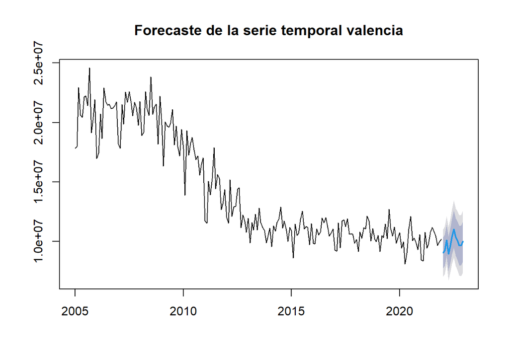

```r
prediccion_valencia <- forecast(modelo_arima_valencia, 12)
plot(prediccion_valencia, main="Forecaste de la serie temporal valencia") # graficar la predicción
```

```r
# Print valores de forcast
prediccion_valencia$mean
```

```
##           Jan      Feb      Mar      Apr      May      Jun      Jul      Aug
## 2022  9040632  9238599 10092226  8956357  9672725 10376281 11030071 10354263
##           Sep      Oct      Nov      Dec
## 2022 10036448  9659995  9634813  9984138
```

Revisar loe errores del modelo

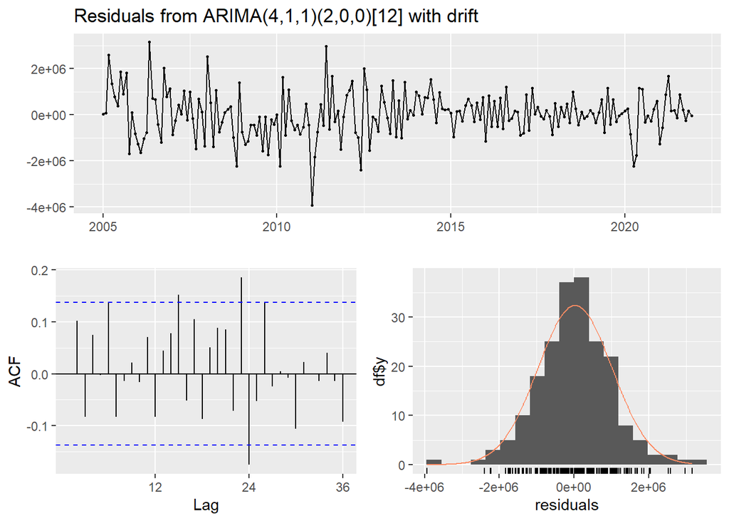

```
##
##  Ljung-Box test
##
## data:  Residuals from ARIMA(4,1,1)(2,0,0)[12] with drift
## Q* = 45.213, df = 17, p-value = 0.0002264
##
## Model df: 7.   Total lags used: 24
```

```r
checkresiduals(modelo_arima_valencia)
```

## Forecast Murcia club_3

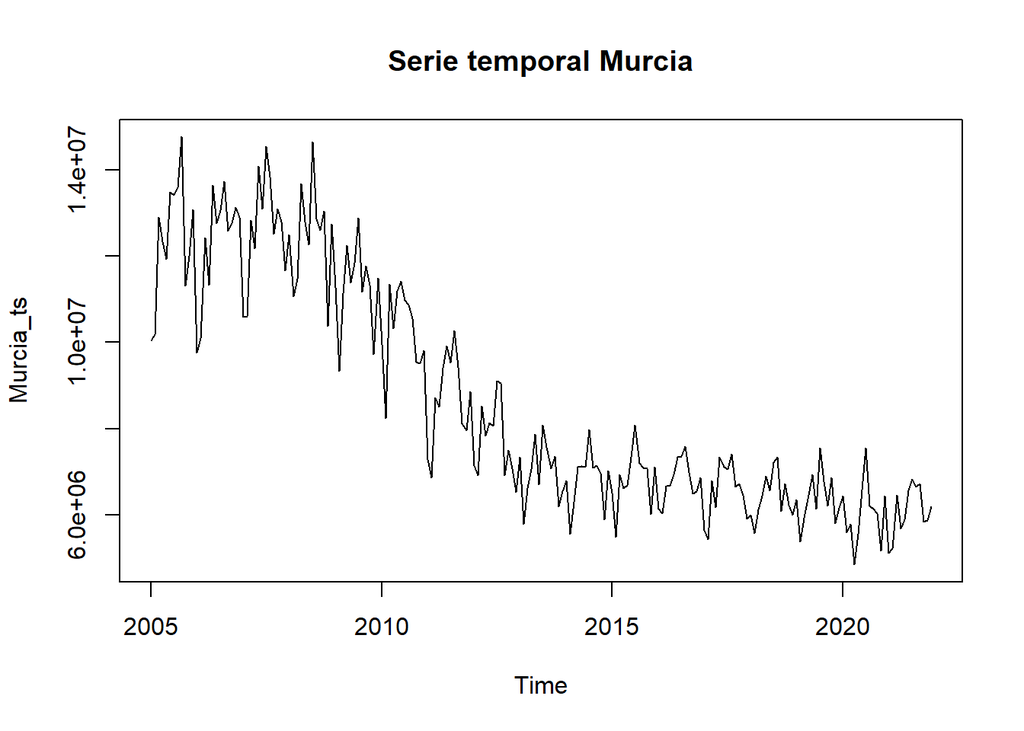

```r
Murcia <- data[data$Provincias == "Murcia",] # Seleccionar la data de Murcia
#view(Murcia)

Murcia_ts <- ts(Murcia$Unidades, start = c(2005, 1), frequency = 12)  #dar formato datatime a la data

plot(Murcia_ts, main="Serie temporal Murcia") #gráficar serie temporal
```

```r
modelo_arima_Murcia <- auto.arima(Murcia_ts)
print(modelo_arima_Murcia) # Mostrar el output del modelo
```

```
## Series: Murcia_ts
## ARIMA(5,1,1)(2,1,1)[12]
##
## Coefficients:
##           ar1      ar2      ar3      ar4      ar5     ma1    sar1     sar2
##       -1.1898  -1.0095  -0.4946  -0.4404  -0.3376  0.3443  -0.101  -0.1364
## s.e.   0.1597   0.1601   0.1604   0.1100   0.0729  0.1612   0.151   0.1095
##          sma1
##       -0.5388
## s.e.   0.1328
##
## sigma^2 = 2.879e+11:  log likelihood = -2790.69
## AIC=5601.38   AICc=5602.6   BIC=5633.9
```

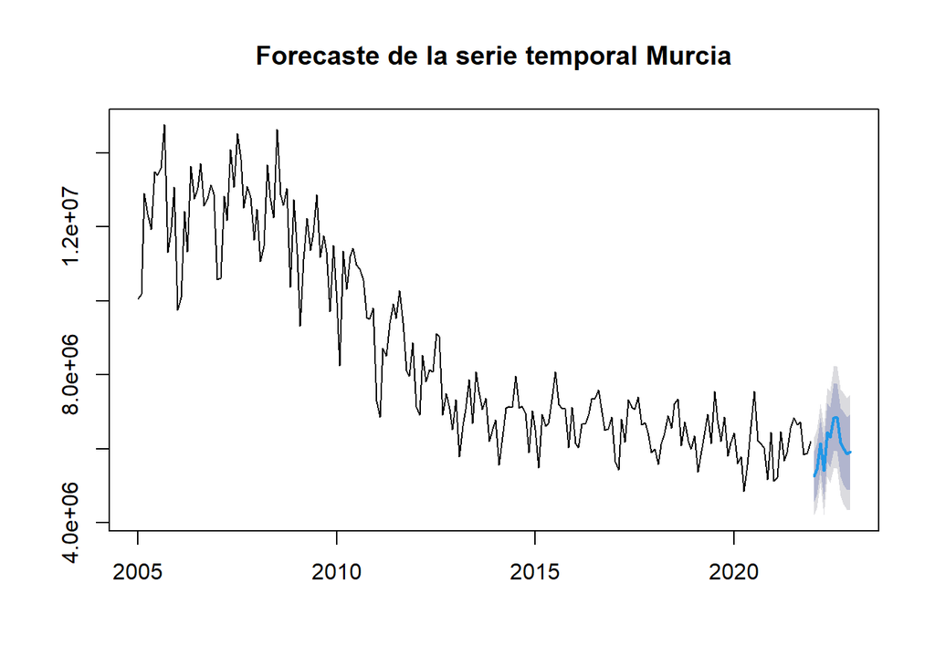

```r
prediccion_Murcia <- forecast(modelo_arima_Murcia, 12)
plot(prediccion_Murcia, main="Forecaste de la serie temporal Murcia") # graficar la predicción
```

```r
prediccion_Murcia$mean
```

```
##          Jan     Feb     Mar     Apr     May     Jun     Jul     Aug     Sep
## 2022 5260729 5459940 6143600 5412303 6444672 6316580 6848224 6849800 6174668
##          Oct     Nov     Dec
## 2022 6021663 5866432 5912500
```

Revisar loe errores del modelo

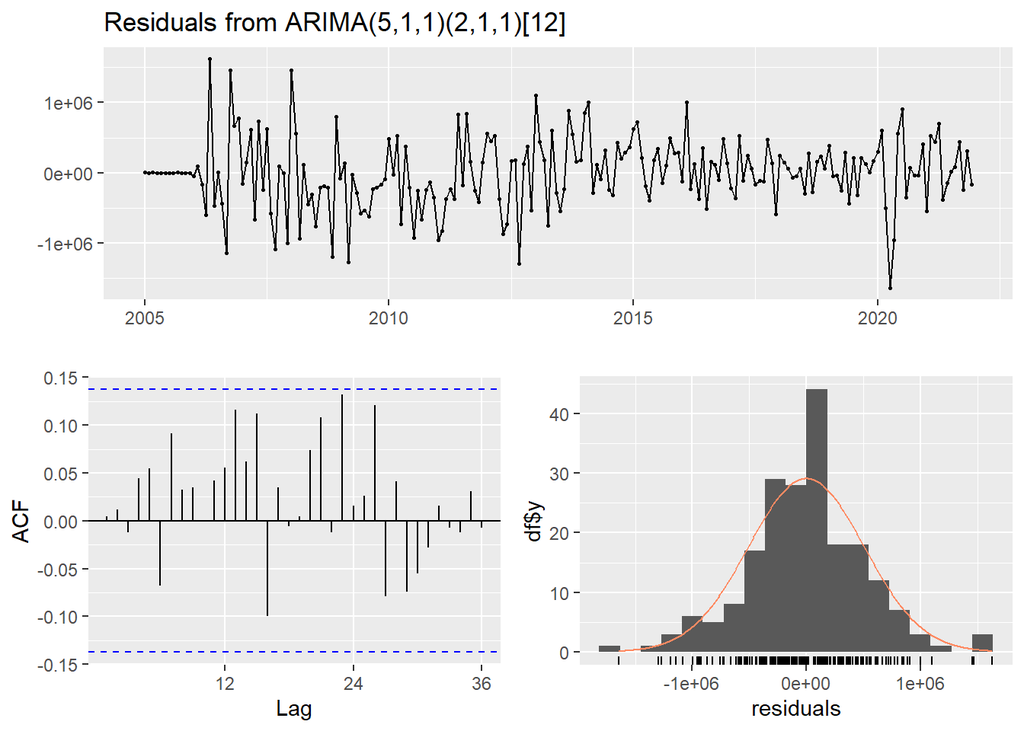

```
##
##  Ljung-Box test
##
## data:  Residuals from ARIMA(5,1,1)(2,1,1)[12]
## Q* = 22.571, df = 15, p-value = 0.09369
##
## Model df: 9.   Total lags used: 24
```

```r
checkresiduals(modelo_arima_Murcia)
```

## Forecast Granada club_4

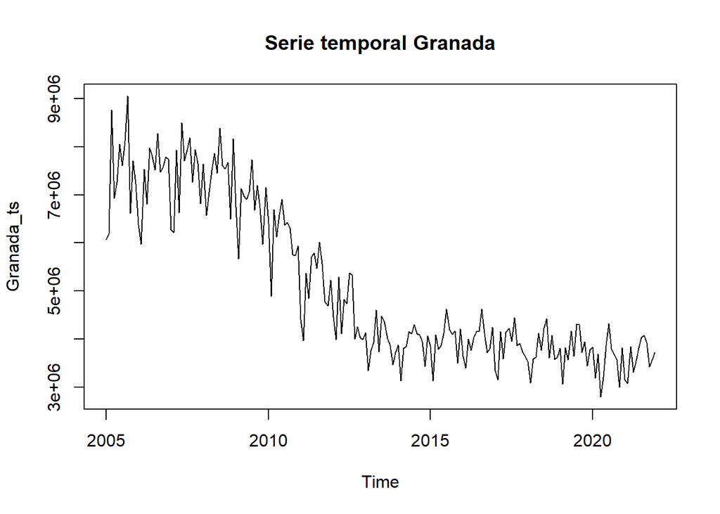

```r
Granada <- data[data$Provincias == "Granada",] # Seleccionar la data de Granada

Granada_ts <- ts(Granada$Unidades, start = c(2005, 1), frequency = 12)  #dar formato datatime a la data

plot(Granada_ts, main="Serie temporal Granada") #gráficar serie temporal
```

```r
modelo_arima_Granada <- auto.arima(Granada_ts)
print(modelo_arima_Granada) # Mostrar el output del modelo
```

```
## Series: Granada_ts
## ARIMA(5,1,3)(2,1,2)[12]
##
## Coefficients:
##          ar1      ar2     ar3      ar4     ar5      ma1     ma2      ma3
##       0.8643  -0.4580  0.4487  -0.4673  0.5153  -1.8010  1.2694  -0.4263
## s.e.  0.1997   0.2212  0.0904   0.1107  0.1311   0.2093  0.4149   0.2378
##          sar1    sar2    sma1     sma2
##       -0.6912  0.1567  0.0367  -0.5827
## s.e.   0.4327  0.1367  0.4318   0.2851
##
## sigma^2 = 1.327e+11:  log likelihood = -2715.5
## AIC=5457.01   AICc=5459.07   BIC=5499.29
```

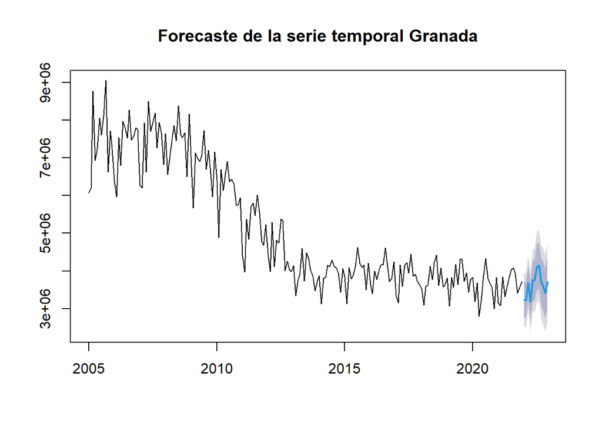

```r
prediccion_Granada <- forecast(modelo_arima_Granada, 12)
plot(prediccion_Granada, main="Forecaste de la serie temporal Granada") # graficar la predicción
```

```r
prediccion_Granada$mean
```

```
##          Jan     Feb     Mar     Apr     May     Jun     Jul     Aug     Sep
## 2022 3227304 3231446 3680684 3186710 3754463 3747801 4096520 4146337 3707946
##          Oct     Nov     Dec
## 2022 3604890 3415730 3707164
```

Revisar loe errores del modelo

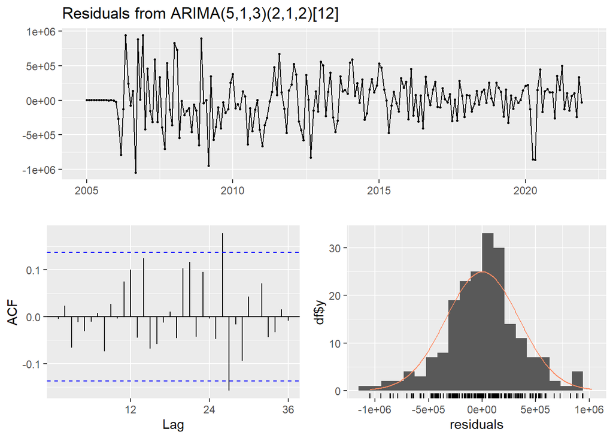

```
##
##  Ljung-Box test
##
## data:  Residuals from ARIMA(5,1,3)(2,1,2)[12]
## Q* = 20.452, df = 12, p-value = 0.05901
##
## Model df: 12.   Total lags used: 24
```

```r
checkresiduals(modelo_arima_Granada)
```

## Forecast Cantabria club_5

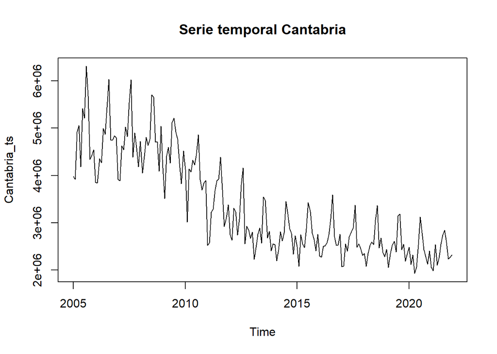

```r
Cantabria <- data[data$Provincias == "Cantabria",] # Seleccionar la data de Cantabria
#view(Cantabria)

Cantabria_ts <- ts(Cantabria$Unidades, start = c(2005, 1), frequency = 12)  #dar formato datatime a la data

plot(Cantabria_ts, main="Serie temporal Cantabria") #gráficar serie temporal
```

```r
modelo_arima_Cantabria <- auto.arima(Cantabria_ts)
print(modelo_arima_Cantabria) # Mostrar el output del modelo
```

```
## Series: Cantabria_ts
## ARIMA(4,1,1)(2,1,2)[12]
##
## Coefficients:
##           ar1      ar2     ar3      ar4      ma1     sar1    sar2     sma1
##       -0.3171  -0.3870  0.0758  -0.2691  -0.5885  -0.6074  0.0710  -0.0561
## s.e.   0.1378   0.1405  0.1243   0.0813   0.1322   0.4600  0.1266   0.4512
##          sma2
##       -0.4097
## s.e.   0.2824
##
## sigma^2 = 6.943e+10:  log likelihood = -2654.7
## AIC=5329.41   AICc=5330.63   BIC=5361.93
```

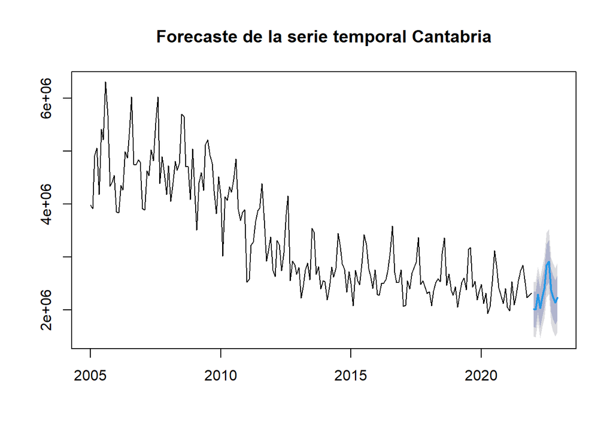

```r
prediccion_Cantabria <- forecast(modelo_arima_Cantabria, 12)
plot(prediccion_Cantabria, main="Forecaste de la serie temporal Cantabria") # graficar la predicción
```

```r
prediccion_Cantabria$mean
```

```
##          Jan     Feb     Mar     Apr     May     Jun     Jul     Aug     Sep
## 2022 2016554 2005978 2296117 2034263 2256983 2410526 2845496 2917878 2368191
##          Oct     Nov     Dec
## 2022 2248577 2143566 2236279
```

Revisar loe errores del modelo

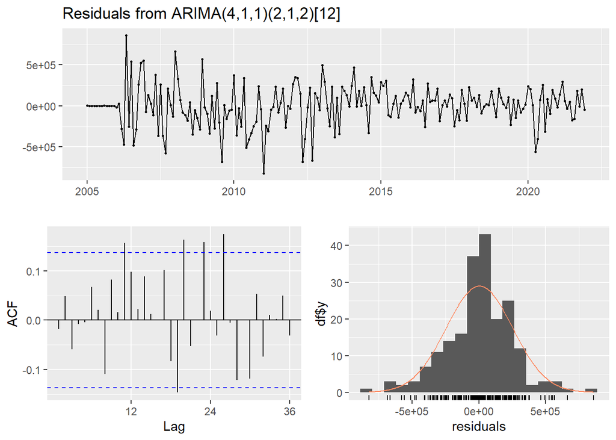

```
##
##  Ljung-Box test
##
## data:  Residuals from ARIMA(4,1,1)(2,1,2)[12]
## Q* = 37.036, df = 15, p-value = 0.00125
##
## Model df: 9.   Total lags used: 24
```

```r
checkresiduals(modelo_arima_Cantabria)
```

## Forecast Huesca club_6

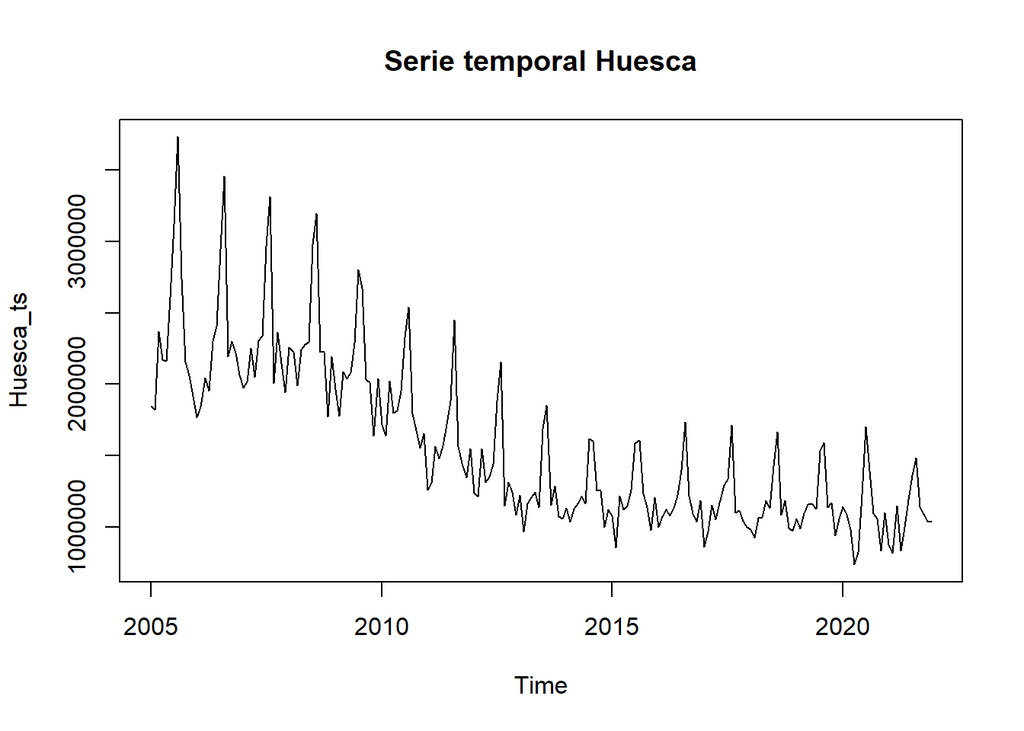

```r
Huesca <- data[data$Provincias == "Huesca",] # Seleccionar la data de Huesca
#view(Huesca)

Huesca_ts <- ts(Huesca$Unidades, start = c(2005, 1), frequency = 12)  #dar formato datatime a la data

plot(Huesca_ts, main="Serie temporal Huesca") #gráficar serie temporal
```

```r
modelo_arima_Huesca <- auto.arima(Huesca_ts)
print(modelo_arima_Cantabria) # Mostrar el output del modelo
```

[output not shown]

```
## Series: Cantabria_ts
## ARIMA(4,1,1)(2,1,2)[12]
##
## Coefficients:
##           ar1      ar2     ar3      ar4      ma1     sar1    sar2     sma1
##       -0.3171  -0.3870  0.0758  -0.2691  -0.5885  -0.6074  0.0710  -0.0561
## s.e.   0.1378   0.1405  0.1243   0.0813   0.1322   0.4600  0.1266   0.4512
##          sma2
##       -0.4097
## s.e.   0.2824
##
## sigma^2 = 6.943e+10:  log likelihood = -2654.7
## AIC=5329.41   AICc=5330.63   BIC=5361.93
```

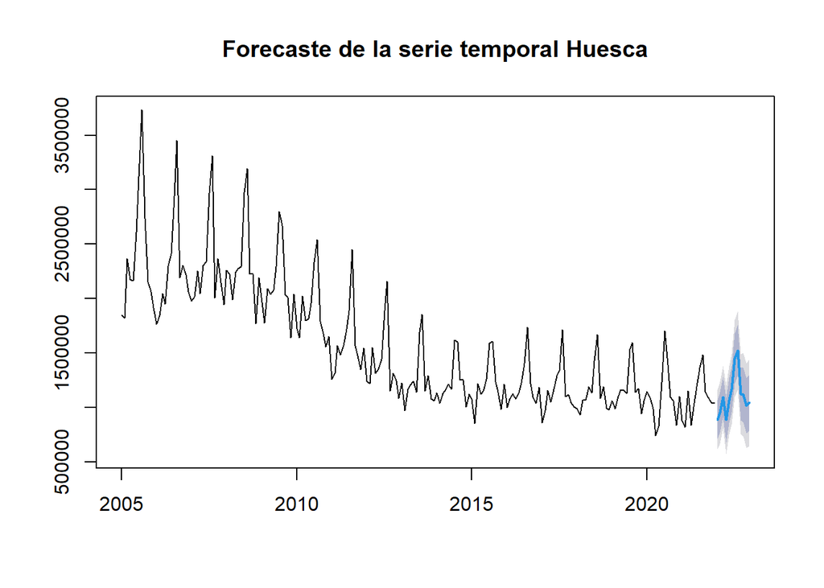

```r
prediccion_Huesca <- forecast(modelo_arima_Huesca, 12)
plot(prediccion_Huesca, main="Forecaste de la serie temporal Huesca") # graficar la predicción
```

```r
prediccion_Huesca$mean
```

```
##            Jan       Feb       Mar       Apr       May       Jun       Jul
## 2022  888852.9  952543.0 1095209.4  884765.3 1065500.6 1165586.7 1448903.0
##            Aug       Sep       Oct       Nov       Dec
## 2022 1523314.8 1122935.4 1116131.9 1017966.3 1044497.0
```

Revisar loe errores del modelo

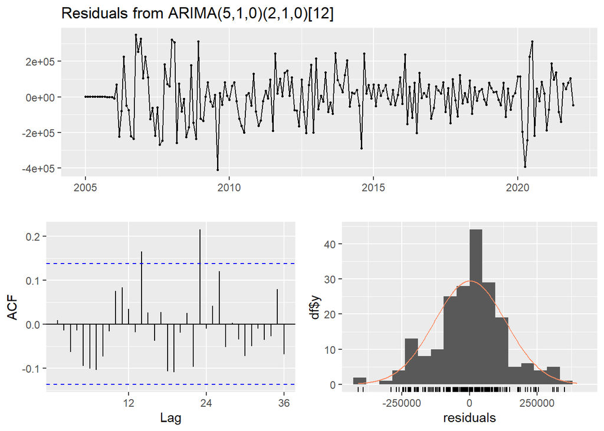

```
##
##  Ljung-Box test
##
## data:  Residuals from ARIMA(5,1,0)(2,1,0)[12]
## Q* = 36.792, df = 17, p-value = 0.003591
##
## Model df: 7.   Total lags used: 24
```

```r
checkresiduals(modelo_arima_Huesca)
```

## Forecast Palencia club_7

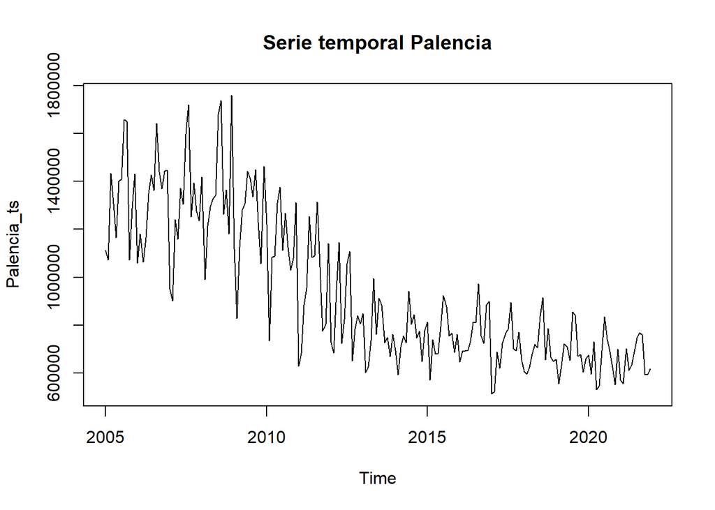

```r
Palencia <- data[data$Provincias == "Palencia",] # Seleccionar la data de Palencia


Palencia_ts <- ts(Palencia$Unidades, start = c(2005, 1), frequency = 12)  #dar formato datatime a la data

plot(Palencia_ts, main="Serie temporal Palencia") #gráficar serie temporal
```

```r
modelo_arima_Palencia <- auto.arima(Palencia_ts)
print(modelo_arima_Palencia) # Mostrar el output del modelo
```

```
## Series: Palencia_ts
## ARIMA(2,1,1)(2,1,0)[12]
##
## Coefficients:
##           ar1      ar2      ma1     sar1     sar2
##       -0.2424  -0.3205  -0.7923  -0.5015  -0.1551
## s.e.   0.0763   0.0747   0.0465   0.0757   0.0765
##
## sigma^2 = 1.66e+10:  log likelihood = -2518.4
## AIC=5048.81   AICc=5049.27   BIC=5068.32
```

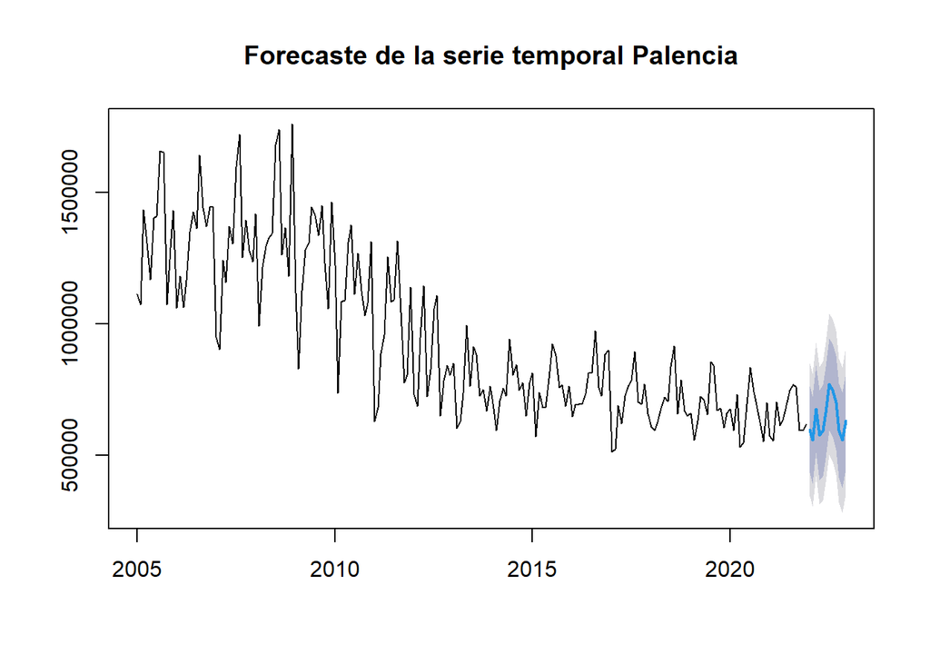

```r
prediccion_Palencia <- forecast(modelo_arima_Palencia, 12)
plot(prediccion_Palencia, main="Forecaste de la serie temporal Palencia") # graficar la predicción
```

```r
prediccion_Palencia$mean
```

```
##           Jan      Feb      Mar      Apr      May      Jun      Jul      Aug
## 2022 596796.0 557080.9 674746.6 574107.7 592686.0 662688.1 768993.7 746854.3
##           Sep      Oct      Nov      Dec
## 2022 698544.9 593384.9 556629.5 629723.5
```

Revisar loe errores del modelo

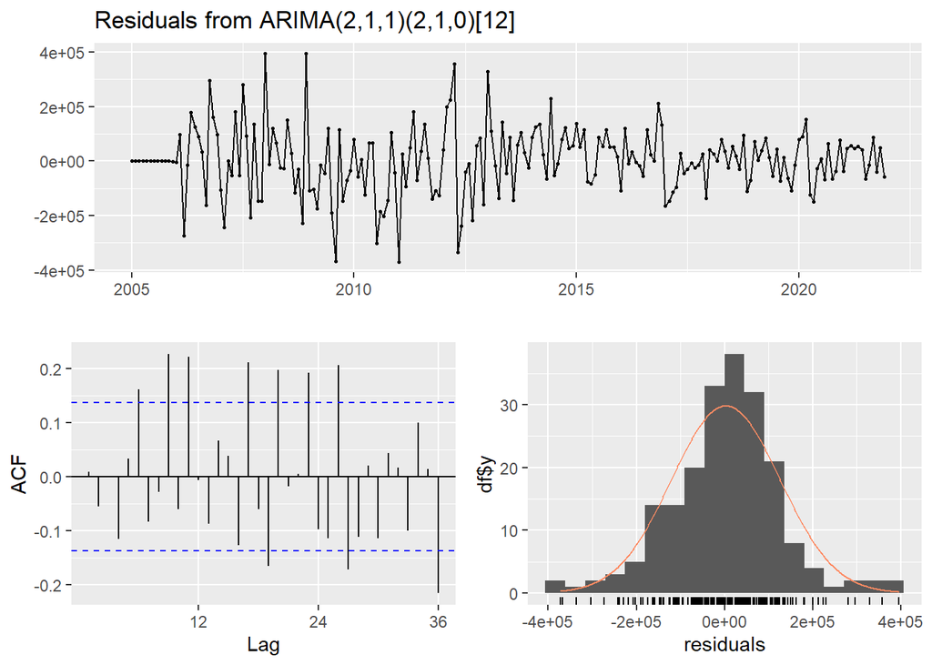

```
##
##  Ljung-Box test
##
## data:  Residuals from ARIMA(2,1,1)(2,1,0)[12]
## Q* = 77.154, df = 19, p-value = 5.725e-09
##
## Model df: 5.   Total lags used: 24
```

```r
checkresiduals(modelo_arima_Palencia)
```